# Project-wide Phenotyping: Factor Models

This notebook quickly harmonises the phenotypic data for the RBC. It includes specifically a harmonised factor score dataset.

```r
library(tidyverse)
library(here)
library(naniar)
```

```r
factors_raw <- readRDS(here("data", "RBC_Psychopathology_factor_scores.Rds")) %>%
  as_tibble()

get_subjects <- function(x){

  list.dirs(x, recursive=FALSE, full.names = FALSE) %>%
    tibble(source=x, participant_id=.) %>%
    filter(str_detect(participant_id, "sub-")) %>%
    return()
}

datasets <- list.dirs("/cbica/projects/RBC/RBC_RAWDATA/bidsdatasets", recursive = FALSE)
imaging_all <- map_df(datasets, get_subjects) %>%
  mutate(study = str_extract(source, "(?<=bidsdatasets\\/).+"))

imaging_all <- get_subjects("/cbica/projects/RBC/RBC_RAWDATA/bidsdatasets/ECAS/BIDS") %>%
  mutate(study = str_extract(source, "(?<=bidsdatasets\\/).+(?=\\/)")) %>%
  bind_rows(imaging_all) %>%
  mutate(study = case_when(
    study == "HRC"   ~ "BHRC",
    study == "ECAS"  ~ "PACCT",
    study == "CCNP"  ~ "Colornest",
    TRUE             ~ study
  ))
```

```r
factors_raw %>%
  left_join(bhrc_subj_labels) %>%
  mutate(participant_id =
           case_when(Study == "ECAS"  ~ str_remove(EID, "_V.+") %>%
                       str_c("sub-", .),
                     Study == "CCNP"  ~ str_remove(EID, "_wave[0-9]+_") %>%
                       str_c("sub-", .),
                     Study == "BHRC"  ~ participant_id,
                     TRUE ~ str_c("sub-", EID)
                     )
         ) %>%
  left_join(ecas_subj_labels, by = c("participant_id" = "original")) %>%
  mutate(participant_id =
           case_when(
             Study == "ECAS" ~ hashed,
             TRUE            ~ participant_id
           )
         ) %>%
  select(participant_id, Study, everything(), -c(old_id, hashed, EID)) -> factor_scores
```

| participant_id | Study | Site | Scale | att_1 | att_2 | att_3 | att_4 | att_5 | emo_1 | emo_2 | emo_3 | emo_4 | emo_5 | emo_6 | emo_7 | emo_8 | emo_9 | emo_10 | emo_11 | emo_12 | emo_13 | emo_14 | ext_1 | ext_2 | ext_3 | ext_4 | ext_5 | ext_6 | ext_7 | … |
| --- | --- | --- | --- | --- | --- | --- | --- | --- | --- | --- | --- | --- | --- | --- | --- | --- | --- | --- | --- | --- | --- | --- | --- | --- | --- | --- | --- | --- | --- | --- |
| sub-NDARHR901YLY | HBN | HBN-3 | CBCL | 0 | 1 | 0 | 0 | 0 | 1 | 1 | 0 | 0 | 0 | 0 | 1 | 0 | 1 | 1 | 1 | 0 | 0 | 1 | 0 | 0 | 0 | 0 | 0 | 0 | 1 | … |
| sub-NDARNT042GRA | HBN | HBN-1 | CBCL | 1 | 1 | 0 | 0 | 1 | 0 | 1 | 0 | 0 | 0 | 0 | 0 | 0 | 0 | 0 | 0 | 0 | 1 | 0 | 0 | 0 | 0 | 1 | 0 | 0 | 0 | … |
| sub-3625162682 | PNC | PNC-1 | GOASSESS | 1 | 1 | 1 | 0 | 1 | 0 | 0 | 0 | 0 | 0 | 0 | 0 | 0 | 0 | 0 | 0 | 0 | 0 | 0 | 0 | 0 | 1 | 0 | 0 | 0 | 0 | … |
| sub-3982145425 | PNC | PNC-1 | GOASSESS | 0 | 0 | 0 | 1 | 1 | 0 | 0 | 0 | 0 | 0 | 0 | 0 | 0 | 0 | 0 | 0 | 0 | 0 | 0 | 0 | 0 | 0 | 0 | 0 | 1 | 1 | … |
| sub-10537 | BHRC | BHRC-1 | CBCL | 0 | 0 | 0 | 0 | 0 | 0 | 0 | 0 | 0 | 0 | 0 | 0 | 0 | 0 | 0 | 0 | 0 | 0 | 0 | 0 | 0 | 0 | 0 | 0 | 0 | 0 | … |
| sub-5adb6d4 | ECAS | ECAS-1 | CBCL | NA | 1 | 1 | 0 | 1 | NA | 1 | 1 | 1 | 1 | 0 | 0 | 0 | 1 | 1 | 0 | 0 | 0 | 0 | 0 | 0 | NA | 0 | 0 | 0 | 0 | … |
| sub-NDARAD615WLJ | HBN | HBN-1 | CBCL | 1 | 0 | 1 | 1 | 0 | 0 | 1 | 0 | 0 | 0 | 0 | 0 | 0 | 1 | 0 | 0 | 0 | 0 | 0 | 0 | 0 | 0 | 0 | 0 | 0 | 1 | … |
| sub-NDARAF003VCL | HBN | HBN-4 | CBCL | 1 | 1 | 1 | 0 | 1 | 0 | 0 | 0 | 0 | 1 | 0 | 0 | 0 | 0 | 0 | 1 | 0 | 1 | 1 | 0 | 1 | 1 | 1 | 1 | 0 | 1 | … |
| sub-10234 | BHRC | BHRC-1 | CBCL | 1 | 1 | 1 | 1 | 0 | 1 | 1 | 1 | 1 | 0 | 1 | 0 | 1 | 0 | 1 | 0 | 0 | 0 | 1 | 0 | 0 | 0 | 1 | 1 | 1 | 0 | … |
| sub-NDARRL030XD8 | HBN | HBN-3 | CBCL | 1 | 1 | 1 | 0 | 0 | 0 | 1 | 0 | 0 | 1 | 0 | 1 | 0 | 0 | 0 | 0 | 0 | 0 | 1 | 0 | 0 | 1 | 1 | 0 | 0 | 0 | … |

[output cut: 20 more lines]

Quick check for completeness:

| participant_id | Study | Site | Scale | att_1 | att_2 | att_3 | att_4 | att_5 | emo_1 | emo_2 | emo_3 | emo_4 | emo_5 | emo_6 | emo_7 | emo_8 | emo_9 | emo_10 | emo_11 | emo_12 | emo_13 | emo_14 | ext_1 | ext_2 | ext_3 | ext_4 | ext_5 | ext_6 | ext_7 | … |
| --- | --- | --- | --- | --- | --- | --- | --- | --- | --- | --- | --- | --- | --- | --- | --- | --- | --- | --- | --- | --- | --- | --- | --- | --- | --- | --- | --- | --- | --- | --- |
| NA | ECAS | ECAS-1 | CBCL | NA | 1 | 1 | 0 | 0 | NA | 0 | 0 | 0 | 0 | 0 | 0 | 0 | 0 | 0 | 0 | 0 | 0 | 0 | 0 | 0 | NA | 1 | 0 | 0 | 1 | … |
| NA | ECAS | ECAS-1 | CBCL | NA | 0 | 0 | 0 | 0 | NA | 0 | 0 | 0 | 1 | 0 | 0 | 0 | 0 | 1 | 0 | 0 | 0 | 0 | 0 | 0 | NA | 0 | 0 | 0 | 1 | … |
| NA | ECAS | ECAS-1 | CBCL | NA | 0 | 0 | 0 | 0 | NA | 0 | 0 | 0 | 0 | 0 | 0 | 0 | 0 | 0 | 0 | 0 | 0 | 0 | 0 | 0 | NA | 0 | 0 | 0 | 0 | … |
| NA | ECAS | ECAS-1 | CBCL | NA | 0 | 0 | 0 | 0 | NA | 0 | 0 | 0 | 0 | 0 | 0 | 0 | 0 | 0 | 0 | 0 | 0 | 0 | 0 | 0 | NA | 0 | 0 | 0 | 0 | … |
| NA | ECAS | ECAS-1 | CBCL | NA | 1 | 0 | 0 | 0 | NA | 0 | 1 | 1 | 1 | 0 | 0 | 0 | 1 | 1 | 1 | 0 | 0 | 0 | 0 | 0 | NA | 0 | 0 | 0 | 0 | … |
| NA | ECAS | ECAS-1 | CBCL | NA | 0 | 1 | 0 | 0 | NA | 0 | 0 | 0 | 0 | 0 | 0 | 0 | 0 | 0 | 0 | 0 | 0 | 0 | 0 | 0 | NA | 0 | 0 | 0 | 0 | … |
| NA | ECAS | ECAS-1 | CBCL | NA | 1 | 1 | 0 | 0 | NA | 0 | 0 | 0 | 0 | 0 | 0 | 0 | 0 | 0 | 0 | 0 | 0 | 0 | 0 | 0 | NA | 0 | 0 | 0 | 0 | … |
| NA | ECAS | ECAS-1 | CBCL | NA | 1 | 1 | 1 | 1 | NA | 1 | 1 | 0 | 0 | 0 | 0 | 1 | 1 | 0 | 0 | 0 | 1 | 1 | 1 | 1 | NA | 1 | 1 | 0 | 1 | … |
| NA | ECAS | ECAS-1 | CBCL | NA | 0 | 0 | 0 | 0 | NA | 0 | 0 | 0 | 0 | 0 | 0 | NA | 0 | 0 | 0 | 0 | 0 | 0 | 0 | 0 | NA | 0 | 0 | 0 | 0 | … |
| NA | ECAS | ECAS-1 | CBCL | NA | 1 | 1 | 0 | 1 | NA | 1 | 1 | 0 | 1 | 0 | 0 | 1 | 1 | 0 | 0 | 0 | 0 | 0 | 0 | 1 | NA | 1 | 1 | 0 | 1 | … |

[output cut: 22 more lines]

These 32 are individuals we haven’t kept imaging data for (filtered out for image data quality).

Joined with imaging dataset:

```r
imaging_all %>%
  left_join(factor_scores) %>%
  select(-Study) %>%
  group_by(study) %>%
  summarise(n_missing = sum(is.na(Scale)),
            perc_missing = (sum(is.na(Scale)) / n() ) * 100)
```

| study | n_missing | perc_missing |
| --- | --- | --- |
| BHRC | 7 | 1.130856 |
| Colornest | 17 | 8.717949 |
| HBN | 98 | 3.753351 |
| HCP-D | 652 | 100.000000 |
| NKI | 1007 | 75.657400 |
| PACCT | 19 | 6.354515 |
| PNC | 0 | 0.000000 |

```r
factors_raw$Study %>% as.factor() %>% summary()
```

```
BHRC CCNP ECAS  HBN  NKI  PNC
2511  181  312 3629  372 1601
```

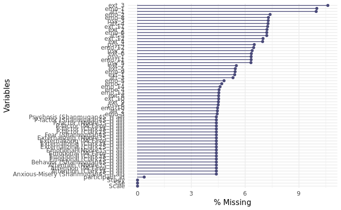

# Using the McElroy Scale

We only use the McElroy scale for publication at this time. The code for generating the McElroy factor scores is demonstrated on OSF:

> All analysis and data processing code for the CBCL models (11 models reviewed from the literature using their full item set) in the [OSF repo](https://osf.io/uwy5n/) This could be used to explain to the future datas user where these scores come from, how they were modeled, their reliability, etc. If they want to use the CBCL full item set model, of course (i.e., non-harmonized or to compare with the GOASSESS-harmonized scores), the code that we used to test the best item-matching strategy is [here](https://osf.io/wnrp4/) but I think this won’t be of much interest in the final RBC data set.

| participant_id | Study | Scale | P-factor (McElroy_H all) | Attention (McElroy_H all) | Emotional (McElroy_H all) | Externalizing (McElroy_H all) |
| --- | --- | --- | --- | --- | --- | --- |
| sub-21610 | BHRC | CBCL | 0.910 | 0.222 | -0.249 | -0.180 |
| sub-NDARCL080RHP | HBN | CBCL | 0.813 | -0.227 | -0.663 | 1.173 |
| sub-A00043282 | NKI | CBCL | 0.367 | -0.147 | -0.730 | -0.049 |
| sub-2323472643 | PNC | GOASSESS | 0.735 | 0.695 | 0.354 | 0.078 |
| sub-A00055728 | NKI | CBCL | -1.054 | -0.417 | 0.614 | -0.089 |
| sub-NDARAC853CR6 | HBN | CBCL | 0.185 | 0.650 | -0.986 | -0.191 |
| sub-283366029 | PNC | GOASSESS | 0.920 | 0.607 | -1.334 | 1.309 |
| sub-A00064418 | NKI | CBCL | -0.143 | -0.944 | 0.648 | -0.770 |
| sub-NDARBM213BEA | HBN | CBCL | 0.346 | 0.123 | 0.982 | -0.022 |
| sub-NDARZH521MMD | HBN | CBCL | 0.099 | 0.570 | 1.100 | -0.045 |

[output cut: 40 more lines]

We’ll write these out to a file:

```r
factor_scores %>%
  select(participant_id, Study, Scale, matches("McElroy")) %>%
  write_tsv(here("outputs", "mcelroy-pfactor-scores.tsv"))
```

And a data dictionary similar to

```
{
  "MeasurementToolMetadata": {
    "Description": "Adult ADHD Clinical Diagnostic Scale V1.2",
    "TermURL": "https://www.cognitiveatlas.org/task/id/trm_5586ff878155d"
  },
  "adhd_b": {
    "Description": "B. CHILDHOOD ONSET OF ADHD (PRIOR TO AGE 7)",
    "Levels": {
      "1": "YES",
      "2": "NO"
    }
  },
  "adhd_c_dx": {
    "Description": "As child met A, B, C, D, E and F diagnostic criteria",
    "Levels": {
      "1": "YES",
      "2": "NO"
    }
  }
}
```

```r
MeasurementToolMetadata <- list(
  "Description" = "McElroy BiFactor Model of Dimensional Psychopathology in Youth",
  "TermURL" = "https://www.medrxiv.org/content/10.1101/2021.06.27.21259601v1"
)

list(MeasurementToolMetadata = MeasurementToolMetadata) %>%
  jsonlite::write_json(here("outputs", "mcelroy-pfactor-scores.json"), auto_unbox=TRUE, pretty=TRUE)
```